# Risk Factor Analysis

## Outcome Variable

**Outcome Variable:** stunted

## Predictor Variables

**Intervention Variable:** single

**Adjustment Set:**

- arm
- W_mage
- W_fage
- meducyrs
- feducyrs
- W_mhtcm
- W_mwtkg
- W_mbmi
- delta_W_mage
- delta_W_fage
- delta_meducyrs
- delta_feducyrs
- delta_W_mhtcm
- delta_W_mwtkg
- delta_W_mbmi

## Stratifying Variables

The analysis was stratified on these variable(s):

- agecat
- studyid
- country

## Data Summary

| agecat | studyid | country | single | stunted | n_cell | n |
| --- | --- | --- | --- | --- | --- | --- |
| Birth | ki0047075b-MAL-ED | BANGLADESH | 0 | 0 | 210 | 257 |
| Birth | ki0047075b-MAL-ED | BANGLADESH | 0 | 1 | 47 | 257 |
| Birth | ki0047075b-MAL-ED | BANGLADESH | 1 | 0 | 0 | 257 |
| Birth | ki0047075b-MAL-ED | BANGLADESH | 1 | 1 | 0 | 257 |
| Birth | ki0047075b-MAL-ED | BRAZIL | 0 | 0 | 151 | 191 |
| Birth | ki0047075b-MAL-ED | BRAZIL | 0 | 1 | 15 | 191 |
| Birth | ki0047075b-MAL-ED | BRAZIL | 1 | 0 | 19 | 191 |
| Birth | ki0047075b-MAL-ED | BRAZIL | 1 | 1 | 6 | 191 |
| Birth | ki0047075b-MAL-ED | INDIA | 0 | 0 | 173 | 205 |
| Birth | ki0047075b-MAL-ED | INDIA | 0 | 1 | 32 | 205 |
| Birth | ki0047075b-MAL-ED | INDIA | 1 | 0 | 0 | 205 |
| Birth | ki0047075b-MAL-ED | INDIA | 1 | 1 | 0 | 205 |
| Birth | ki0047075b-MAL-ED | NEPAL | 0 | 0 | 155 | 173 |
| Birth | ki0047075b-MAL-ED | NEPAL | 0 | 1 | 18 | 173 |
| Birth | ki0047075b-MAL-ED | NEPAL | 1 | 0 | 0 | 173 |
| Birth | ki0047075b-MAL-ED | NEPAL | 1 | 1 | 0 | 173 |
| Birth | ki0047075b-MAL-ED | PERU | 0 | 0 | 226 | 287 |
| Birth | ki0047075b-MAL-ED | PERU | 0 | 1 | 27 | 287 |
| Birth | ki0047075b-MAL-ED | PERU | 1 | 0 | 27 | 287 |
| Birth | ki0047075b-MAL-ED | PERU | 1 | 1 | 7 | 287 |
| Birth | ki0047075b-MAL-ED | SOUTH AFRICA | 0 | 0 | 133 | 262 |
| Birth | ki0047075b-MAL-ED | SOUTH AFRICA | 0 | 1 | 13 | 262 |
| Birth | ki0047075b-MAL-ED | SOUTH AFRICA | 1 | 0 | 101 | 262 |
| Birth | ki0047075b-MAL-ED | SOUTH AFRICA | 1 | 1 | 15 | 262 |
| Birth | ki0047075b-MAL-ED | TANZANIA, UNITED REPUBLIC OF | 0 | 0 | 100 | 123 |
| Birth | ki0047075b-MAL-ED | TANZANIA, UNITED REPUBLIC OF | 0 | 1 | 17 | 123 |
| Birth | ki0047075b-MAL-ED | TANZANIA, UNITED REPUBLIC OF | 1 | 0 | 5 | 123 |
| Birth | ki0047075b-MAL-ED | TANZANIA, UNITED REPUBLIC OF | 1 | 1 | 1 | 123 |
| Birth | ki1119695-PROBIT | BELARUS | 0 | 0 | 13312 | 13884 |
| Birth | ki1119695-PROBIT | BELARUS | 0 | 1 | 31 | 13884 |

[output cut: 126 more lines]

The following strata were considered:

- agecat: 24 months, studyid: ki0047075b-MAL-ED, country: BANGLADESH
- agecat: 24 months, studyid: ki0047075b-MAL-ED, country: BRAZIL
- agecat: 24 months, studyid: ki0047075b-MAL-ED, country: INDIA
- agecat: 24 months, studyid: ki0047075b-MAL-ED, country: NEPAL
- agecat: 24 months, studyid: ki0047075b-MAL-ED, country: PERU
- agecat: 24 months, studyid: ki0047075b-MAL-ED, country: SOUTH AFRICA
- agecat: 24 months, studyid: ki0047075b-MAL-ED, country: TANZANIA, UNITED REPUBLIC OF
- agecat: 24 months, studyid: ki1066203-TanzaniaChild2, country: TANZANIA, UNITED REPUBLIC OF
- agecat: 24 months, studyid: ki1119695-PROBIT, country: BELARUS
- agecat: 24 months, studyid: ki1126311-ZVITAMBO, country: ZIMBABWE
- agecat: 24 months, studyid: ki1135781-COHORTS, country: GUATEMALA
- agecat: 24 months, studyid: ki1135781-COHORTS, country: INDIA
- agecat: 24 months, studyid: ki1135781-COHORTS, country: PHILIPPINES
- agecat: 6 months, studyid: ki0047075b-MAL-ED, country: BANGLADESH
- agecat: 6 months, studyid: ki0047075b-MAL-ED, country: BRAZIL
- agecat: 6 months, studyid: ki0047075b-MAL-ED, country: INDIA
- agecat: 6 months, studyid: ki0047075b-MAL-ED, country: NEPAL
- agecat: 6 months, studyid: ki0047075b-MAL-ED, country: PERU
- agecat: 6 months, studyid: ki0047075b-MAL-ED, country: SOUTH AFRICA
- agecat: 6 months, studyid: ki0047075b-MAL-ED, country: TANZANIA, UNITED REPUBLIC OF
- agecat: 6 months, studyid: ki1066203-TanzaniaChild2, country: TANZANIA, UNITED REPUBLIC OF
- agecat: 6 months, studyid: ki1112895-Guatemala BSC, country: GUATEMALA
- agecat: 6 months, studyid: ki1119695-PROBIT, country: BELARUS
- agecat: 6 months, studyid: ki1126311-ZVITAMBO, country: ZIMBABWE
- agecat: 6 months, studyid: ki1135781-COHORTS, country: GUATEMALA
- agecat: 6 months, studyid: ki1135781-COHORTS, country: INDIA
- agecat: 6 months, studyid: ki1135781-COHORTS, country: PHILIPPINES
- agecat: Birth, studyid: ki0047075b-MAL-ED, country: BANGLADESH
- agecat: Birth, studyid: ki0047075b-MAL-ED, country: BRAZIL
- agecat: Birth, studyid: ki0047075b-MAL-ED, country: INDIA
- agecat: Birth, studyid: ki0047075b-MAL-ED, country: NEPAL
- agecat: Birth, studyid: ki0047075b-MAL-ED, country: PERU
- agecat: Birth, studyid: ki0047075b-MAL-ED, country: SOUTH AFRICA
- agecat: Birth, studyid: ki0047075b-MAL-ED, country: TANZANIA, UNITED REPUBLIC OF
- agecat: Birth, studyid: ki1119695-PROBIT, country: BELARUS
- agecat: Birth, studyid: ki1126311-ZVITAMBO, country: ZIMBABWE
- agecat: Birth, studyid: ki1135781-COHORTS, country: GUATEMALA
- agecat: Birth, studyid: ki1135781-COHORTS, country: INDIA
- agecat: Birth, studyid: ki1135781-COHORTS, country: PHILIPPINES

### Dropped Strata

Some strata were dropped due to rare outcomes:

- agecat: Birth, studyid: ki0047075b-MAL-ED, country: BANGLADESH
- agecat: Birth, studyid: ki0047075b-MAL-ED, country: INDIA
- agecat: Birth, studyid: ki0047075b-MAL-ED, country: NEPAL
- agecat: Birth, studyid: ki0047075b-MAL-ED, country: TANZANIA, UNITED REPUBLIC OF
- agecat: Birth, studyid: ki1119695-PROBIT, country: BELARUS
- agecat: Birth, studyid: ki1135781-COHORTS, country: INDIA
- agecat: 6 months, studyid: ki0047075b-MAL-ED, country: BANGLADESH
- agecat: 6 months, studyid: ki0047075b-MAL-ED, country: BRAZIL
- agecat: 6 months, studyid: ki0047075b-MAL-ED, country: INDIA
- agecat: 6 months, studyid: ki0047075b-MAL-ED, country: NEPAL
- agecat: 6 months, studyid: ki0047075b-MAL-ED, country: TANZANIA, UNITED REPUBLIC OF
- agecat: 6 months, studyid: ki1135781-COHORTS, country: INDIA
- agecat: 24 months, studyid: ki0047075b-MAL-ED, country: BANGLADESH
- agecat: 24 months, studyid: ki0047075b-MAL-ED, country: BRAZIL
- agecat: 24 months, studyid: ki0047075b-MAL-ED, country: INDIA
- agecat: 24 months, studyid: ki0047075b-MAL-ED, country: NEPAL
- agecat: 24 months, studyid: ki0047075b-MAL-ED, country: TANZANIA, UNITED REPUBLIC OF
- agecat: 24 months, studyid: ki1066203-TanzaniaChild2, country: TANZANIA, UNITED REPUBLIC OF
- agecat: 24 months, studyid: ki1135781-COHORTS, country: INDIA

## Methods Detail

We’re interested in the causal parameters $E[Y_a]$ for all values of $a \in \mathcal{A}$. These parameters represent the mean outcome if, possibly contrary to fact, we intervened to set all units to have $A=a$. Under the randomization and positivity assumptions, these are identified by the statistical parameters $\psi_a=E_W[E_{Y|A,W}(Y|A=a,W)]$. In addition, we’re interested in the mean of $Y$, $E[Y]$ under no intervention (the observed mean). We will estimate these parameters by using SuperLearner to fit the relevant likelihood factors – $E_{Y|A,W}(Y|A=a,W)$ and $p(A=a|W)$, and then updating our likelihood fit using a joint TMLE.

For unadjusted analyses ($W=\{\}$), initial likelihoods were estimated using Lrnr_glm to estimate the simple $E(Y|A)$ and Lrnr_mean to estimate $p(A)$. For adjusted analyses, a small library containing Lrnr_glmnet, Lrnr_xgboost, and Lrnr_mean was used.

Having estimated these parameters, we will then use the delta method to estimate relative risks and attributable risks relative to a prespecified baseline level of $A$.

# Results Detail

## Results Plots

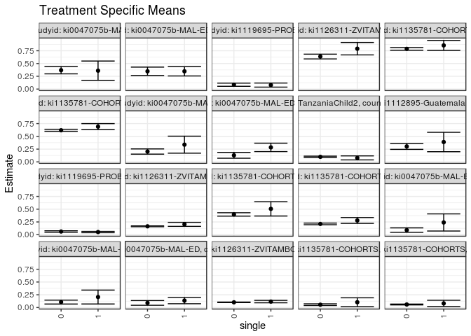

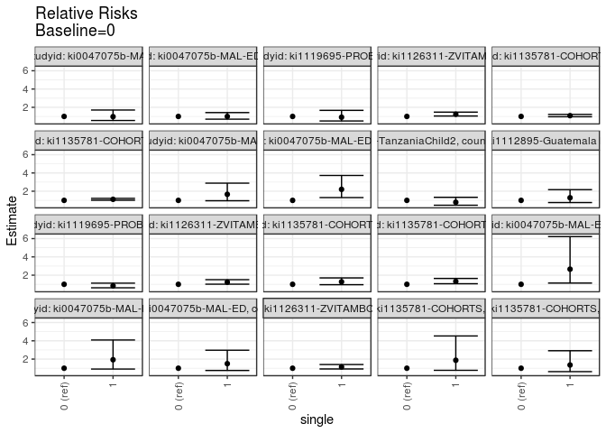

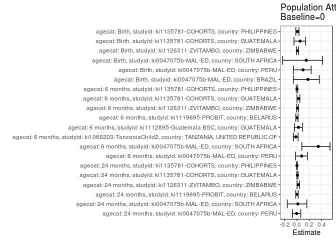

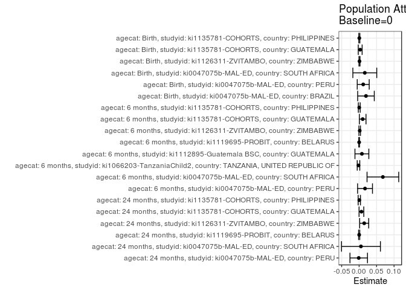

## Results Table

### Parameter: TSM

| agecat | studyid | country | intervention_level | baseline_level | estimate | ci_lower | ci_upper |
| --- | --- | --- | --- | --- | --- | --- | --- |
| Birth | ki0047075b-MAL-ED | BRAZIL | 0 | NA | 0.0903614 | 0.0466334 | 0.1340895 |
| Birth | ki0047075b-MAL-ED | BRAZIL | 1 | NA | 0.2400000 | 0.0721465 | 0.4078535 |
| Birth | ki0047075b-MAL-ED | PERU | 0 | NA | 0.1067194 | 0.0686074 | 0.1448313 |
| Birth | ki0047075b-MAL-ED | PERU | 1 | NA | 0.2058824 | 0.0697321 | 0.3420326 |
| Birth | ki0047075b-MAL-ED | SOUTH AFRICA | 0 | NA | 0.0906269 | 0.0442959 | 0.1369579 |
| Birth | ki0047075b-MAL-ED | SOUTH AFRICA | 1 | NA | 0.1358239 | 0.0744815 | 0.1971664 |
| Birth | ki1126311-ZVITAMBO | ZIMBABWE | 0 | NA | 0.1025638 | 0.0973015 | 0.1078260 |
| Birth | ki1126311-ZVITAMBO | ZIMBABWE | 1 | NA | 0.1167236 | 0.0928322 | 0.1406149 |
| Birth | ki1135781-COHORTS | GUATEMALA | 0 | NA | 0.0556328 | 0.0388678 | 0.0723978 |
| Birth | ki1135781-COHORTS | GUATEMALA | 1 | NA | 0.1041667 | 0.0176920 | 0.1906413 |
| Birth | ki1135781-COHORTS | PHILIPPINES | 0 | NA | 0.0599455 | 0.0513537 | 0.0685373 |
| Birth | ki1135781-COHORTS | PHILIPPINES | 1 | NA | 0.0810811 | 0.0199126 | 0.1422496 |
| 6 months | ki0047075b-MAL-ED | PERU | 0 | NA | 0.2028820 | 0.1518137 | 0.2539504 |
| 6 months | ki0047075b-MAL-ED | PERU | 1 | NA | 0.3372997 | 0.1710262 | 0.5035732 |
| 6 months | ki0047075b-MAL-ED | SOUTH AFRICA | 0 | NA | 0.1288302 | 0.0719587 | 0.1857016 |
| 6 months | ki0047075b-MAL-ED | SOUTH AFRICA | 1 | NA | 0.2840787 | 0.2017935 | 0.3663639 |
| 6 months | ki1066203-TanzaniaChild2 | TANZANIA, UNITED REPUBLIC OF | 0 | NA | 0.0986441 | 0.0849970 | 0.1122913 |
| 6 months | ki1066203-TanzaniaChild2 | TANZANIA, UNITED REPUBLIC OF | 1 | NA | 0.0782401 | 0.0389683 | 0.1175120 |
| 6 months | ki1112895-Guatemala BSC | GUATEMALA | 0 | NA | 0.3025368 | 0.2450669 | 0.3600067 |
| 6 months | ki1112895-Guatemala BSC | GUATEMALA | 1 | NA | 0.3892073 | 0.1991935 | 0.5792211 |
| 6 months | ki1119695-PROBIT | BELARUS | 0 | NA | 0.0626502 | 0.0485116 | 0.0767888 |
| 6 months | ki1119695-PROBIT | BELARUS | 1 | NA | 0.0522703 | 0.0393040 | 0.0652367 |
| 6 months | ki1126311-ZVITAMBO | ZIMBABWE | 0 | NA | 0.1645758 | 0.1563214 | 0.1728301 |
| 6 months | ki1126311-ZVITAMBO | ZIMBABWE | 1 | NA | 0.2029771 | 0.1637068 | 0.2422474 |
| 6 months | ki1135781-COHORTS | GUATEMALA | 0 | NA | 0.3973944 | 0.3640634 | 0.4307254 |
| 6 months | ki1135781-COHORTS | GUATEMALA | 1 | NA | 0.5065179 | 0.3660420 | 0.6469939 |
| 6 months | ki1135781-COHORTS | PHILIPPINES | 0 | NA | 0.2115307 | 0.1955753 | 0.2274861 |
| 6 months | ki1135781-COHORTS | PHILIPPINES | 1 | NA | 0.2790937 | 0.2219463 | 0.3362412 |
| 24 months | ki0047075b-MAL-ED | PERU | 0 | NA | 0.3693182 | 0.2978389 | 0.4407975 |
| 24 months | ki0047075b-MAL-ED | PERU | 1 | NA | 0.3600000 | 0.1713737 | 0.5486263 |
| 24 months | ki0047075b-MAL-ED | SOUTH AFRICA | 0 | NA | 0.3476759 | 0.2654566 | 0.4298952 |
| 24 months | ki0047075b-MAL-ED | SOUTH AFRICA | 1 | NA | 0.3478760 | 0.2567790 | 0.4389731 |
| 24 months | ki1119695-PROBIT | BELARUS | 0 | NA | 0.0851237 | 0.0544040 | 0.1158435 |
| 24 months | ki1119695-PROBIT | BELARUS | 1 | NA | 0.0780110 | 0.0381850 | 0.1178370 |
| 24 months | ki1126311-ZVITAMBO | ZIMBABWE | 0 | NA | 0.6368039 | 0.5903712 | 0.6832365 |
| 24 months | ki1126311-ZVITAMBO | ZIMBABWE | 1 | NA | 0.7906977 | 0.6689718 | 0.9124235 |
| 24 months | ki1135781-COHORTS | GUATEMALA | 0 | NA | 0.7870996 | 0.7607524 | 0.8134467 |
| 24 months | ki1135781-COHORTS | GUATEMALA | 1 | NA | 0.8550629 | 0.7571406 | 0.9529851 |
| 24 months | ki1135781-COHORTS | PHILIPPINES | 0 | NA | 0.6191331 | 0.5991645 | 0.6391016 |
| 24 months | ki1135781-COHORTS | PHILIPPINES | 1 | NA | 0.6904949 | 0.6314097 | 0.7495800 |

### Parameter: E(Y)

| agecat | studyid | country | intervention_level | baseline_level | estimate | ci_lower | ci_upper |
| --- | --- | --- | --- | --- | --- | --- | --- |
| Birth | ki0047075b-MAL-ED | BRAZIL | NA | NA | 0.1099476 | 0.0654669 | 0.1544284 |
| Birth | ki0047075b-MAL-ED | PERU | NA | NA | 0.1184669 | 0.0810142 | 0.1559196 |
| Birth | ki0047075b-MAL-ED | SOUTH AFRICA | NA | NA | 0.1068702 | 0.0693890 | 0.1443514 |
| Birth | ki1126311-ZVITAMBO | ZIMBABWE | NA | NA | 0.1036160 | 0.0985259 | 0.1087061 |
| Birth | ki1135781-COHORTS | GUATEMALA | NA | NA | 0.0586701 | 0.0420278 | 0.0753124 |
| Birth | ki1135781-COHORTS | PHILIPPINES | NA | NA | 0.0604651 | 0.0519489 | 0.0689813 |
| 6 months | ki0047075b-MAL-ED | PERU | NA | NA | 0.2197802 | 0.1705687 | 0.2689917 |
| 6 months | ki0047075b-MAL-ED | SOUTH AFRICA | NA | NA | 0.1968504 | 0.1478551 | 0.2458457 |
| 6 months | ki1066203-TanzaniaChild2 | TANZANIA, UNITED REPUBLIC OF | NA | NA | 0.0968703 | 0.0839461 | 0.1097946 |
| 6 months | ki1112895-Guatemala BSC | GUATEMALA | NA | NA | 0.3104693 | 0.2558835 | 0.3650551 |
| 6 months | ki1119695-PROBIT | BELARUS | NA | NA | 0.0626864 | 0.0488489 | 0.0765238 |
| 6 months | ki1126311-ZVITAMBO | ZIMBABWE | NA | NA | 0.1662432 | 0.1582164 | 0.1742700 |
| 6 months | ki1135781-COHORTS | GUATEMALA | NA | NA | 0.4076148 | 0.3753675 | 0.4398620 |
| 6 months | ki1135781-COHORTS | PHILIPPINES | NA | NA | 0.2118834 | 0.1963977 | 0.2273691 |
| 24 months | ki0047075b-MAL-ED | PERU | NA | NA | 0.3681592 | 0.3013164 | 0.4350020 |
| 24 months | ki0047075b-MAL-ED | SOUTH AFRICA | NA | NA | 0.3529412 | 0.2921001 | 0.4137823 |
| 24 months | ki1119695-PROBIT | BELARUS | NA | NA | 0.0852540 | 0.0554439 | 0.1150642 |
| 24 months | ki1126311-ZVITAMBO | ZIMBABWE | NA | NA | 0.6513158 | 0.6075279 | 0.6951037 |
| 24 months | ki1135781-COHORTS | GUATEMALA | NA | NA | 0.7936821 | 0.7687506 | 0.8186137 |
| 24 months | ki1135781-COHORTS | PHILIPPINES | NA | NA | 0.6196192 | 0.6002567 | 0.6389817 |

### Parameter: RR

| agecat | studyid | country | intervention_level | baseline_level | estimate | ci_lower | ci_upper |
| --- | --- | --- | --- | --- | --- | --- | --- |
| Birth | ki0047075b-MAL-ED | BRAZIL | 0 | 0 | 1.0000000 | 1.0000000 | 1.000000 |
| Birth | ki0047075b-MAL-ED | BRAZIL | 1 | 0 | 2.6560000 | 1.1346616 | 6.217128 |
| Birth | ki0047075b-MAL-ED | PERU | 0 | 0 | 1.0000000 | 1.0000000 | 1.000000 |
| Birth | ki0047075b-MAL-ED | PERU | 1 | 0 | 1.9291939 | 0.9098576 | 4.090518 |
| Birth | ki0047075b-MAL-ED | SOUTH AFRICA | 0 | 0 | 1.0000000 | 1.0000000 | 1.000000 |
| Birth | ki0047075b-MAL-ED | SOUTH AFRICA | 1 | 0 | 1.4987160 | 0.7557606 | 2.972038 |
| Birth | ki1126311-ZVITAMBO | ZIMBABWE | 0 | 0 | 1.0000000 | 1.0000000 | 1.000000 |
| Birth | ki1126311-ZVITAMBO | ZIMBABWE | 1 | 0 | 1.1380586 | 0.9215645 | 1.405412 |
| Birth | ki1135781-COHORTS | GUATEMALA | 0 | 0 | 1.0000000 | 1.0000000 | 1.000000 |
| Birth | ki1135781-COHORTS | GUATEMALA | 1 | 0 | 1.8723958 | 0.7741873 | 4.528447 |
| Birth | ki1135781-COHORTS | PHILIPPINES | 0 | 0 | 1.0000000 | 1.0000000 | 1.000000 |
| Birth | ki1135781-COHORTS | PHILIPPINES | 1 | 0 | 1.3525799 | 0.6275750 | 2.915145 |
| 6 months | ki0047075b-MAL-ED | PERU | 0 | 0 | 1.0000000 | 1.0000000 | 1.000000 |
| 6 months | ki0047075b-MAL-ED | PERU | 1 | 0 | 1.6625411 | 0.9584465 | 2.883878 |
| 6 months | ki0047075b-MAL-ED | SOUTH AFRICA | 0 | 0 | 1.0000000 | 1.0000000 | 1.000000 |
| 6 months | ki0047075b-MAL-ED | SOUTH AFRICA | 1 | 0 | 2.2050638 | 1.3056361 | 3.724090 |
| 6 months | ki1066203-TanzaniaChild2 | TANZANIA, UNITED REPUBLIC OF | 0 | 0 | 1.0000000 | 1.0000000 | 1.000000 |
| 6 months | ki1066203-TanzaniaChild2 | TANZANIA, UNITED REPUBLIC OF | 1 | 0 | 0.7931552 | 0.4714430 | 1.334404 |
| 6 months | ki1112895-Guatemala BSC | GUATEMALA | 0 | 0 | 1.0000000 | 1.0000000 | 1.000000 |
| 6 months | ki1112895-Guatemala BSC | GUATEMALA | 1 | 0 | 1.2864793 | 0.7612107 | 2.174206 |
| 6 months | ki1119695-PROBIT | BELARUS | 0 | 0 | 1.0000000 | 1.0000000 | 1.000000 |
| 6 months | ki1119695-PROBIT | BELARUS | 1 | 0 | 0.8343200 | 0.6181205 | 1.126140 |
| 6 months | ki1126311-ZVITAMBO | ZIMBABWE | 0 | 0 | 1.0000000 | 1.0000000 | 1.000000 |
| 6 months | ki1126311-ZVITAMBO | ZIMBABWE | 1 | 0 | 1.2333354 | 1.0103218 | 1.505576 |
| 6 months | ki1135781-COHORTS | GUATEMALA | 0 | 0 | 1.0000000 | 1.0000000 | 1.000000 |
| 6 months | ki1135781-COHORTS | GUATEMALA | 1 | 0 | 1.2745976 | 0.9556158 | 1.700055 |
| 6 months | ki1135781-COHORTS | PHILIPPINES | 0 | 0 | 1.0000000 | 1.0000000 | 1.000000 |
| 6 months | ki1135781-COHORTS | PHILIPPINES | 1 | 0 | 1.3194006 | 1.0608122 | 1.641024 |
| 24 months | ki0047075b-MAL-ED | PERU | 0 | 0 | 1.0000000 | 1.0000000 | 1.000000 |
| 24 months | ki0047075b-MAL-ED | PERU | 1 | 0 | 0.9747692 | 0.5575963 | 1.704056 |
| 24 months | ki0047075b-MAL-ED | SOUTH AFRICA | 0 | 0 | 1.0000000 | 1.0000000 | 1.000000 |
| 24 months | ki0047075b-MAL-ED | SOUTH AFRICA | 1 | 0 | 1.0005756 | 0.7034002 | 1.423303 |
| 24 months | ki1119695-PROBIT | BELARUS | 0 | 0 | 1.0000000 | 1.0000000 | 1.000000 |
| 24 months | ki1119695-PROBIT | BELARUS | 1 | 0 | 0.9164419 | 0.5041294 | 1.665973 |
| 24 months | ki1126311-ZVITAMBO | ZIMBABWE | 0 | 0 | 1.0000000 | 1.0000000 | 1.000000 |
| 24 months | ki1126311-ZVITAMBO | ZIMBABWE | 1 | 0 | 1.2416659 | 1.0471916 | 1.472256 |
| 24 months | ki1135781-COHORTS | GUATEMALA | 0 | 0 | 1.0000000 | 1.0000000 | 1.000000 |
| 24 months | ki1135781-COHORTS | GUATEMALA | 1 | 0 | 1.0863465 | 0.9640141 | 1.224203 |
| 24 months | ki1135781-COHORTS | PHILIPPINES | 0 | 0 | 1.0000000 | 1.0000000 | 1.000000 |
| 24 months | ki1135781-COHORTS | PHILIPPINES | 1 | 0 | 1.1152608 | 1.0186133 | 1.221078 |

### Parameter: PAR

| agecat | studyid | country | intervention_level | baseline_level | estimate | ci_lower | ci_upper |
| --- | --- | --- | --- | --- | --- | --- | --- |
| Birth | ki0047075b-MAL-ED | BRAZIL | 0 | NA | 0.0195862 | -0.0042246 | 0.0433970 |
| Birth | ki0047075b-MAL-ED | PERU | 0 | NA | 0.0117475 | -0.0054086 | 0.0289037 |
| Birth | ki0047075b-MAL-ED | SOUTH AFRICA | 0 | NA | 0.0162434 | -0.0179871 | 0.0504738 |
| Birth | ki1126311-ZVITAMBO | ZIMBABWE | 0 | NA | 0.0010523 | -0.0004408 | 0.0025453 |
| Birth | ki1135781-COHORTS | GUATEMALA | 0 | NA | 0.0030373 | -0.0025377 | 0.0086123 |
| Birth | ki1135781-COHORTS | PHILIPPINES | 0 | NA | 0.0005196 | -0.0010290 | 0.0020683 |
| 6 months | ki0047075b-MAL-ED | PERU | 0 | NA | 0.0168982 | -0.0044412 | 0.0382375 |
| 6 months | ki0047075b-MAL-ED | SOUTH AFRICA | 0 | NA | 0.0680202 | 0.0226367 | 0.1134037 |
| 6 months | ki1066203-TanzaniaChild2 | TANZANIA, UNITED REPUBLIC OF | 0 | NA | -0.0017738 | -0.0054495 | 0.0019019 |
| 6 months | ki1112895-Guatemala BSC | GUATEMALA | 0 | NA | 0.0079325 | -0.0119492 | 0.0278142 |
| 6 months | ki1119695-PROBIT | BELARUS | 0 | NA | 0.0000362 | -0.0010950 | 0.0011673 |
| 6 months | ki1126311-ZVITAMBO | ZIMBABWE | 0 | NA | 0.0016674 | -0.0005169 | 0.0038517 |
| 6 months | ki1135781-COHORTS | GUATEMALA | 0 | NA | 0.0102204 | 0.0007510 | 0.0196898 |
| 6 months | ki1135781-COHORTS | PHILIPPINES | 0 | NA | 0.0003527 | -0.0023182 | 0.0030236 |
| 24 months | ki0047075b-MAL-ED | PERU | 0 | NA | -0.0011590 | -0.0262516 | 0.0239336 |
| 24 months | ki0047075b-MAL-ED | SOUTH AFRICA | 0 | NA | 0.0052653 | -0.0504365 | 0.0609670 |
| 24 months | ki1119695-PROBIT | BELARUS | 0 | NA | 0.0001303 | -0.0015606 | 0.0018212 |
| 24 months | ki1126311-ZVITAMBO | ZIMBABWE | 0 | NA | 0.0145119 | 0.0015502 | 0.0274736 |
| 24 months | ki1135781-COHORTS | GUATEMALA | 0 | NA | 0.0065826 | -0.0001597 | 0.0133249 |
| 24 months | ki1135781-COHORTS | PHILIPPINES | 0 | NA | 0.0004862 | -0.0028185 | 0.0037908 |

### Parameter: PAF

| agecat | studyid | country | intervention_level | baseline_level | estimate | ci_lower | ci_upper |
| --- | --- | --- | --- | --- | --- | --- | --- |
| Birth | ki0047075b-MAL-ED | BRAZIL | 0 | NA | 0.1781411 | -0.0569878 | 0.3609652 |
| Birth | ki0047075b-MAL-ED | PERU | 0 | NA | 0.0991630 | -0.0549019 | 0.2307272 |
| Birth | ki0047075b-MAL-ED | SOUTH AFRICA | 0 | NA | 0.1519915 | -0.2305999 | 0.4156359 |
| Birth | ki1126311-ZVITAMBO | ZIMBABWE | 0 | NA | 0.0101556 | -0.0043532 | 0.0244547 |
| Birth | ki1135781-COHORTS | GUATEMALA | 0 | NA | 0.0517694 | -0.0470659 | 0.1412754 |
| Birth | ki1135781-COHORTS | PHILIPPINES | 0 | NA | 0.0085936 | -0.0173296 | 0.0338562 |
| 6 months | ki0047075b-MAL-ED | PERU | 0 | NA | 0.0768868 | -0.0247395 | 0.1684345 |
| 6 months | ki0047075b-MAL-ED | SOUTH AFRICA | 0 | NA | 0.3455428 | 0.0801903 | 0.5343447 |
| 6 months | ki1066203-TanzaniaChild2 | TANZANIA, UNITED REPUBLIC OF | 0 | NA | -0.0183111 | -0.0569013 | 0.0188700 |
| 6 months | ki1112895-Guatemala BSC | GUATEMALA | 0 | NA | 0.0255501 | -0.0406475 | 0.0875367 |
| 6 months | ki1119695-PROBIT | BELARUS | 0 | NA | 0.0005767 | -0.0176621 | 0.0184886 |
| 6 months | ki1126311-ZVITAMBO | ZIMBABWE | 0 | NA | 0.0100301 | -0.0031907 | 0.0230767 |
| 6 months | ki1135781-COHORTS | GUATEMALA | 0 | NA | 0.0250736 | 0.0015385 | 0.0480540 |
| 6 months | ki1135781-COHORTS | PHILIPPINES | 0 | NA | 0.0016647 | -0.0110327 | 0.0142026 |
| 24 months | ki0047075b-MAL-ED | PERU | 0 | NA | -0.0031480 | -0.0736742 | 0.0627455 |
| 24 months | ki0047075b-MAL-ED | SOUTH AFRICA | 0 | NA | 0.0149182 | -0.1562538 | 0.1607499 |
| 24 months | ki1119695-PROBIT | BELARUS | 0 | NA | 0.0015281 | -0.0187913 | 0.0214423 |
| 24 months | ki1126311-ZVITAMBO | ZIMBABWE | 0 | NA | 0.0222809 | 0.0020242 | 0.0421265 |
| 24 months | ki1135781-COHORTS | GUATEMALA | 0 | NA | 0.0082937 | -0.0002630 | 0.0167772 |
| 24 months | ki1135781-COHORTS | PHILIPPINES | 0 | NA | 0.0007846 | -0.0045656 | 0.0061063 |